# Visualisations

2023-03-17

# SD, SEM and different plot types

## SD vs SEM

Standard deviation is defined as

$$\sigma = \sqrt{\frac{\sum_{i=0}^n (x_i -
\overline{x})^2}{n - 1}}$$

Standard error of the mean (SEM) is defined as

$$\sigma_{M} =
\frac{\sigma}{\sqrt{n}}$$

Usually, when we increase the sample size, $\sigma$ remains more or less the same, but $\sigma_M$ decreases. Therefore, SEM is not a good measure of variation in population.

Below, we generate four samples with four different sizes. We use normal distrubtion with mean = 20 and standard deviation = 1.

```r
## generate mock data sets with different sample sizes
ns <- c(10, 50, 100, 500)
data <- rnorm(sum(ns), mean=20)
## repeat "a" 10 times, "b" 50 times, etc.
labs <- unlist(lapply(1:length(ns),
  function(i) rep(letters[i], ns[i])))

## calculate means, SD and SEM
means <- tapply(data, labs, mean)
sds <- tapply(data, labs, sd)
ses <- sds/sqrt(ns)
```

```r
ebar <- function(x, y, sd, width=1, ...) {
  w <- width/2

  segments(x, y, x, y + sd, ...)
  segments(x - w, y + sd, x + w, y + sd, ...)
}
```

## SD vs SEM (cont.)

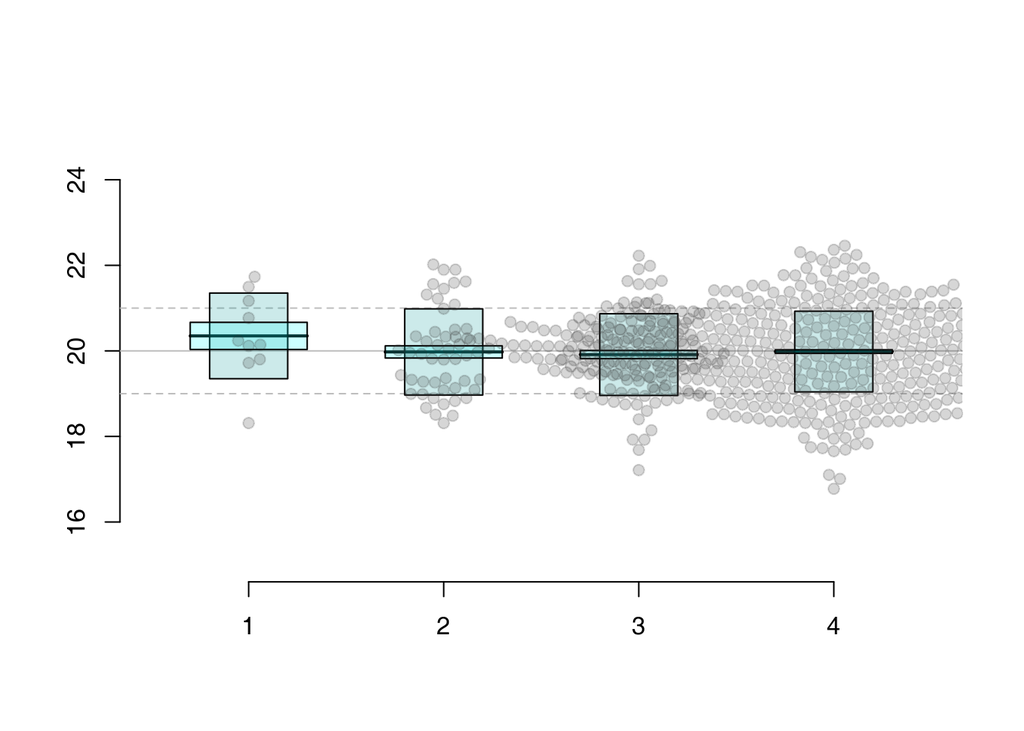

Very often, you see the following incorrect representation of the data:

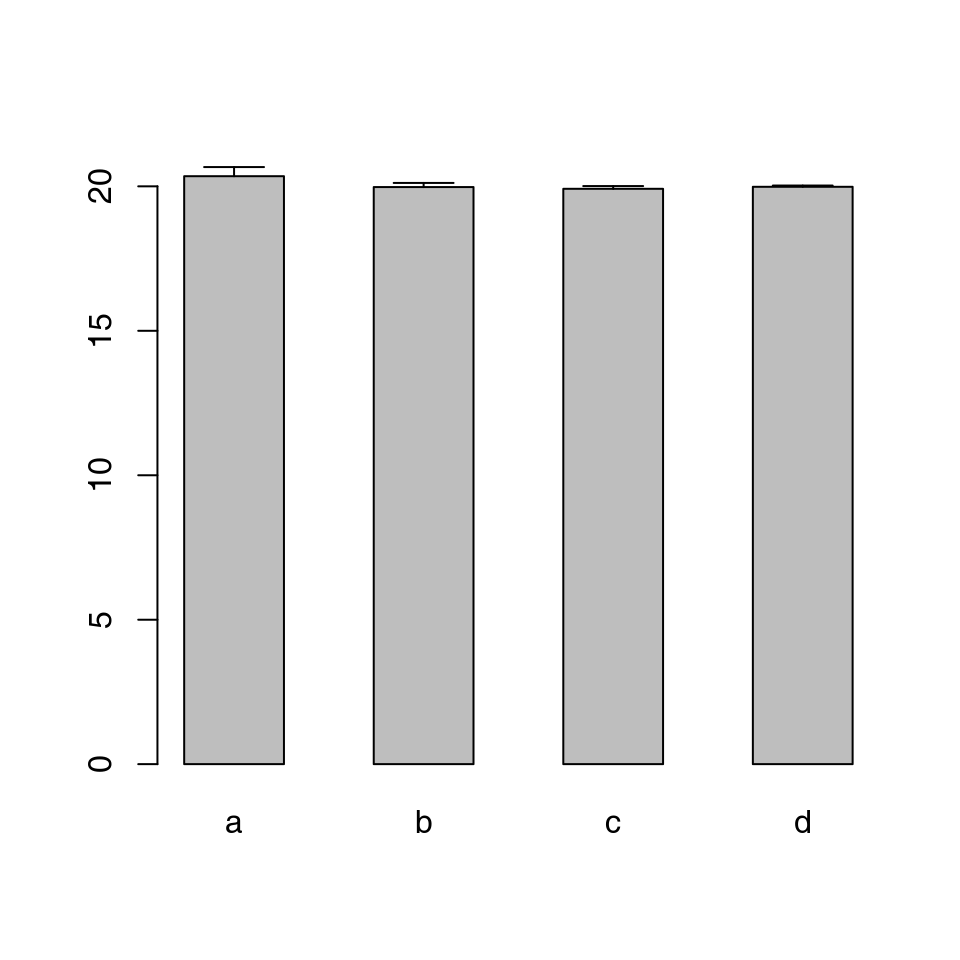

```r
bp <- barplot(means, ylim=c(0, 21), space=.9)
ebar(bp[,1], means, ses, width=.6)
```

(Do not use bar plots for such data! See [Kick the bar char habit](https://www.nature.com/articles/nmeth.2837) for details.)

This is also why you should not use SEM in your plots. Below are a few correct representations of the data:

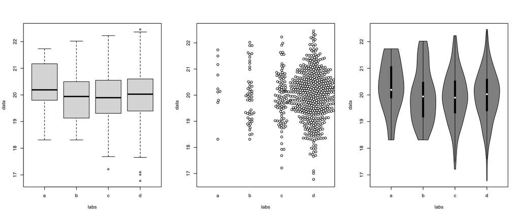

```r
# the line below means: create three plots on one figure
par(mfrow=c(1,3))

boxplot(data ~ labs)
beeswarm(data ~ labs)
vioplot(data ~ labs)
```

And now the ggplot2 versions:

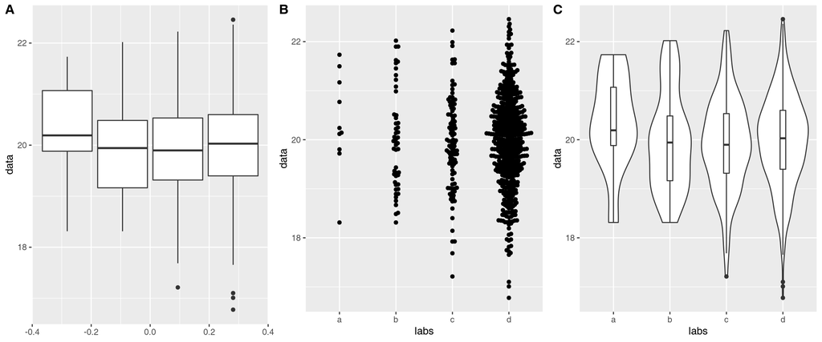

```r
# ggplot2 requires a data frame with the data
df <- data.frame(data=data, labs=labs)

p1 <- ggplot(df, aes(y=data, group=labs)) + geom_boxplot()
p2 <- ggplot(df, aes(x=labs, y=data, group=labs)) + geom_beeswarm()
p3 <- ggplot(df, aes(x=labs, y=data, group=labs)) + geom_violin() +
  geom_boxplot(width=0.1)
plot_grid(p1, p2, p3, nrow=1, labels=LETTERS[1:3])
```

Note: we achieved to get three plots labeled on one figure using the `plot_grid` function from the `cowplot` package.

Let us set the ggplot theme to “minimal”, so the plots are a bit nicer:

```r
theme_set(theme_minimal())
plot_grid(p1, p2, p3, nrow=1)
```

[output not shown]

# Bar plots

Bar plots are useful when you have proportion data. For example, you want to change how the fraction of mutants in your population changes with time.

Bar plots are suitable for frequency data or if you have numbers (total numbers of something), but not for other data types. Specifically, using them to show the results of QPCR (fold changes / log fold changes / $\Delta\Delta$ values) is incorrect.

First, we will generate some random data for three time points.

You do not need to inspect the code below, but feel free to do it.

```r
df <- data.frame(time_point=rep(c("t1", "t2", "t3"), each=2),
                 strain=rep(c("WT", "KO"), 3),
                 fraction=c(.9, .1, .7, .3, .5, .5))
print(df)
```

[output not shown]

Base R:

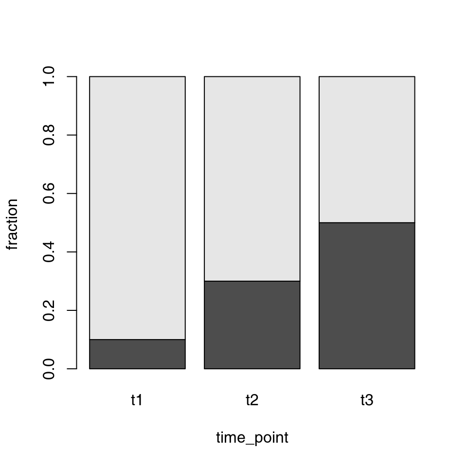

```r
barplot(fraction ~ strain + time_point, data=df)
```

ggplot2:

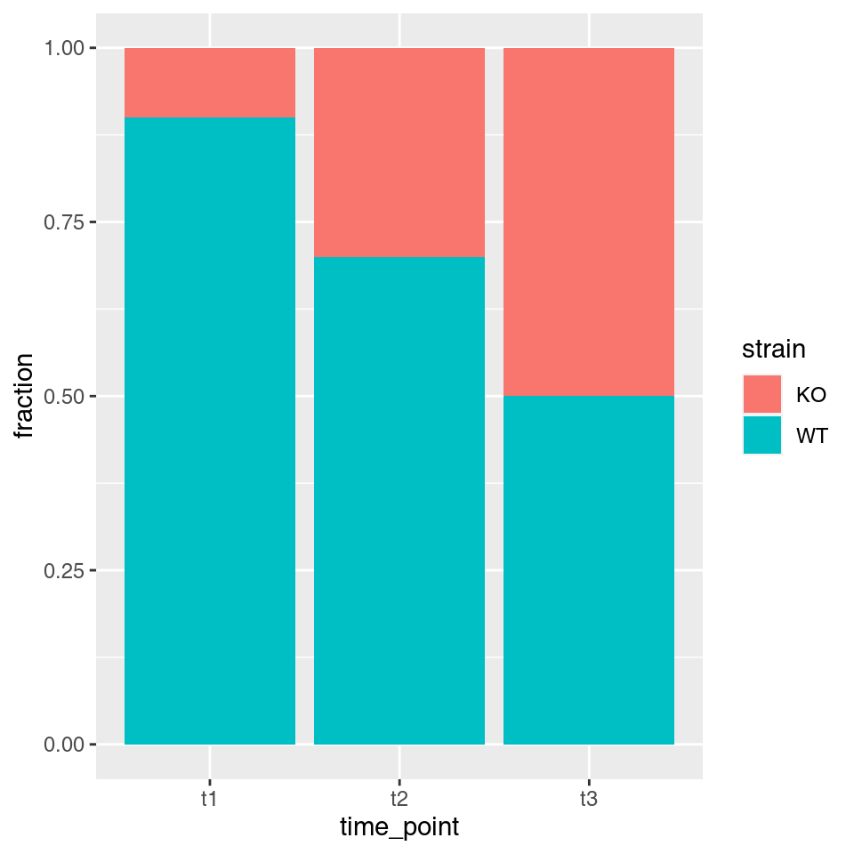

```r
ggplot(df, aes(x=time_point, y=fraction, fill=strain)) +
  geom_bar(stat="identity")
```

# Linear regression

## Calculating linear regression

We use the `mtcars` data set and calculate how fuel consumption (`mpg`) depends on the horsepower (`hp`).

```r
mod1 <- lm(mpg ~ hp, data=mtcars)
summary(mod1)
mod2 <- lm(mpg ~ hp + disp, data=mtcars)
summary(mod2)
```

[output not shown]

## Plotting linear regression: basic

Plotting mod2 would be less trivial, since we only show one predictor variable on the plot, but the model depends on two of them.

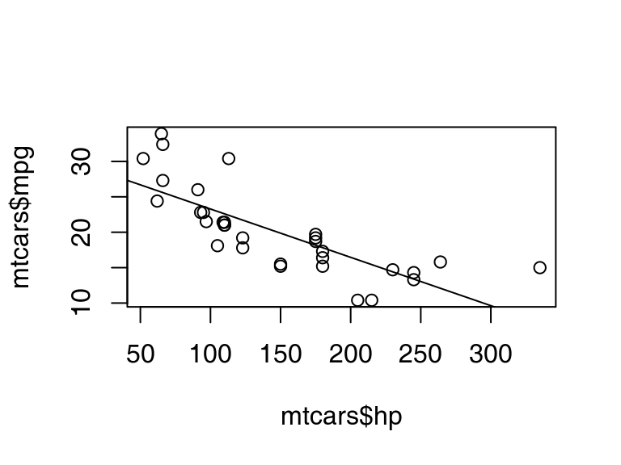

```r
plot(mtcars$hp, mtcars$mpg)
abline(mod1)
```

In ggplot2:

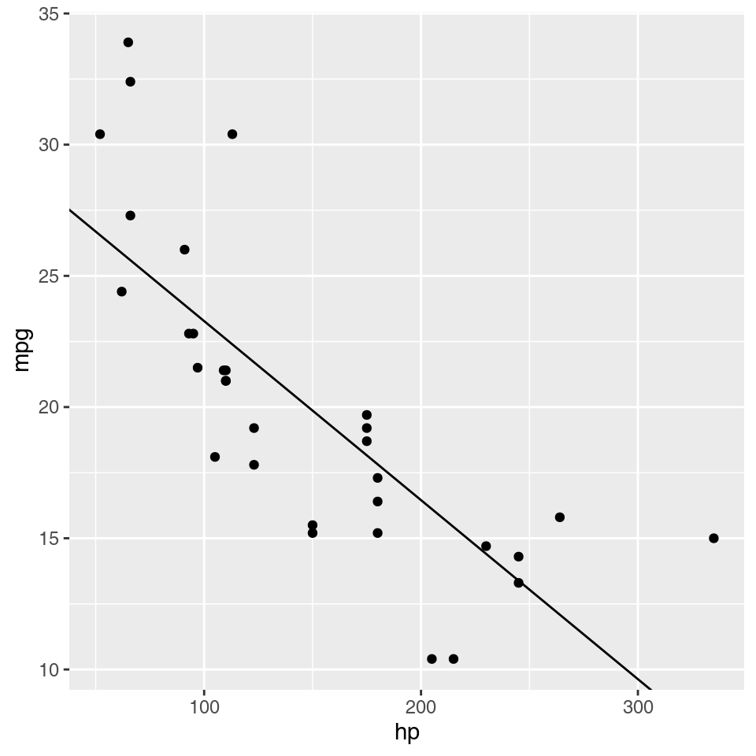

```r
ggplot(mtcars, aes(x=hp, y=mpg)) + geom_point() +
  geom_abline(intercept=mod1$coefficients[1], slope=mod1$coefficients[2])
```

Alternatively, we can directly fit the regression model in ggplot:

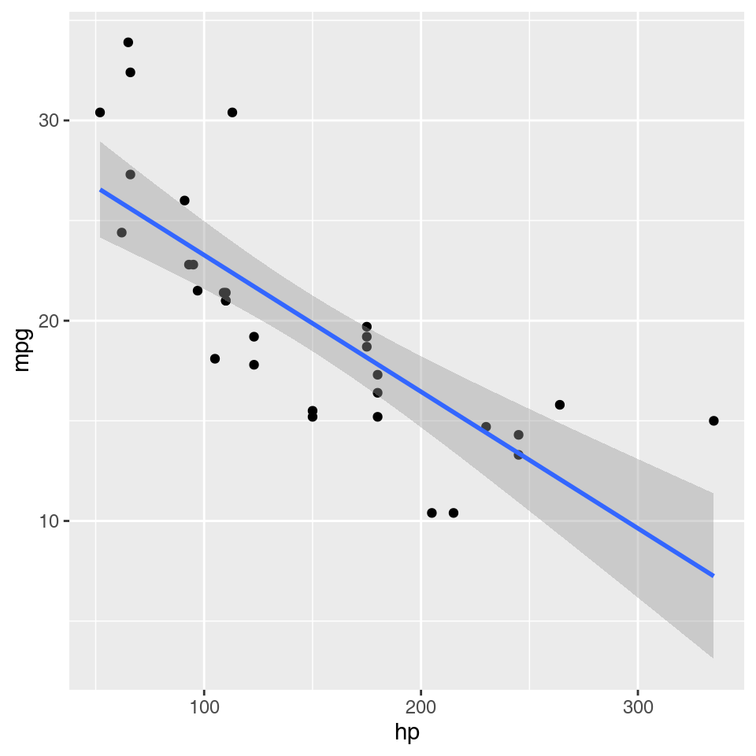

```r
ggplot(mtcars, aes(x=hp, y=mpg)) +
  geom_point() +
  geom_smooth(method="lm")
```

Above, you have already the regression confidence intervals.

## Comparing models

We ask the question whether mod2 is significantly better than mod1. For that, we use a simple ANOVA. We also include another model, using log(hp) rather than hp, and compare all three using Bayesian Information Criterion. Models with a smaller BIC (or lower Akaike Information Criterion, AIC) are better.

```r
mod1 <- lm(mpg ~ hp, data=mtcars)
summary(mod1)
mod2 <- lm(mpg ~ hp + disp, data=mtcars)
summary(mod2)
anova(mod1, mod2)
mod.l <- lm(mpg ~ log(hp), data=mtcars)
BIC(mod1, mod2, mod.l)
```

[output not shown]

## Plotting linear regression

Confidence intervals tell us how well we have estimated the relationship. Prediction intervals tell us how well we can predict new data points using this model. Below, we calculate the regression confidence and prediction intervals manually.

```r
mod <- lm(mpg ~ log(hp), data=mtcars)
xnew <- 50:350
plot(mtcars$hp, mtcars$mpg, log="x", xlab="HP",
  ylab="MPG", bty="n")
ci <- predict(mod, newdata=data.frame(hp=xnew), interval="conf")
lines(xnew, ci[,1], lwd=2) # fit
lines(xnew, ci[,2]) # lower CI
lines(xnew, ci[,3]) # upper CI
pr <- predict(mod, newdata=data.frame(hp=xnew), interval="pred")
lines(xnew, pr[,2], lty=2) # lower prediction
lines(xnew, pr[,3], lty=2) # upper prediction
```

## Plotting linear regression (cont.)

[figure not shown]

Now with a nicer colors (using polygons):

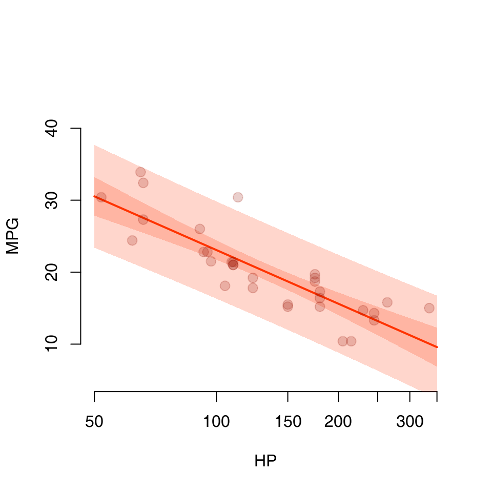

```r
plot(NULL, xlim=c(50,350), ylim=c(5,45), log="x", xlab="HP",
  ylab="MPG", bty="n")
x2 <- c(ci$hp, rev(ci$hp))
polygon(x2, c(pr$lwr, rev(pr$upr)), col="#FF330033", border=NA)
polygon(x2, c(ci$lwr, rev(ci$upr)), col="#FF330033", border=NA)
lines(ci$hp, ci$fit, col="#FF3300", lwd=2) # fit
points(mtcars$hp, mtcars$mpg, pch=19, cex=1.3, col="#99110033")
```

## Plotting the intervals in ggplot2

The ggplot2 `geom_smooth` is capable of calculating automatically the confidence intervals, but it does not do the prediction intervals which are very often more interesting. To include them, we need to manually add a corresponding polygon.

To use a logarithmic scale, we include the `scale_x_log10`.

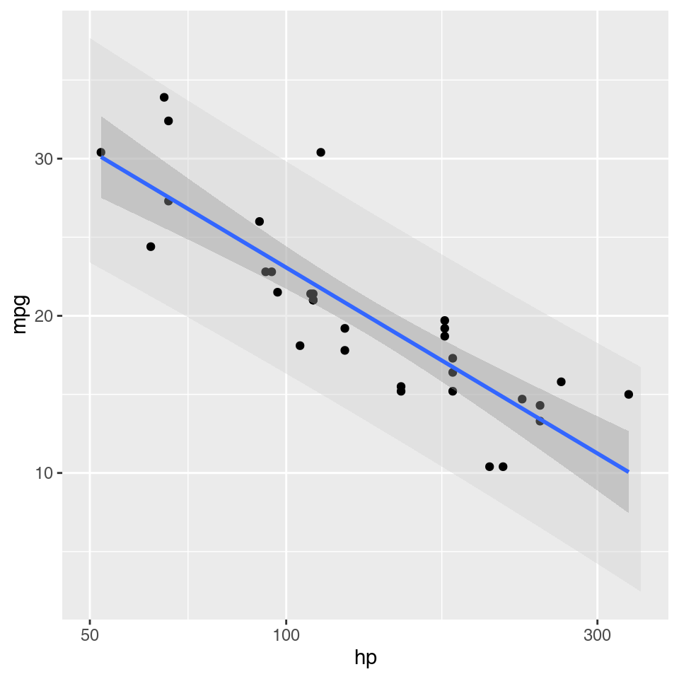

```r
ggplot(mtcars, aes(x=hp, y=mpg)) +
  scale_x_log10() +
  geom_ribbon(data=pr, aes(x=hp, y=fit, ymin=lwr, ymax=upr),
              fill="lightgrey", alpha=.4) +
  geom_point() +
  geom_smooth(method="lm")
```

# Heatmaps

## loading data

```r
genes <- read_xlsx("Datasets/expression_data_vaccination_example.xlsx",
  sheet=2)
e <- read_xlsx("Datasets/expression_data_vaccination_example.xlsx",
  sheet=3)
t <- read_xlsx("Datasets/expression_data_vaccination_example.xlsx",
  sheet=1)
res <- read.csv("Datasets/transcriptomics_results.csv")

## res and genes are not identical!
com <- intersect(genes$ProbeName, res$ProbeName)
e <- data.matrix(e[ match(com, genes$ProbeName), ])
genes <- genes[ match(com, genes$ProbeName), ]
rownames(e) <- genes$GeneName
res <- res[ match(com, res$ProbeName), ]
all(res$ProbeName == genes$ProbeName)
```

## Selecting genes to plot on a heatmap

```r
n <- 25 # top 50
byqval <- order(res$qval.F.D1)
sel <- byqval[1:n]

downreg <- which(res$logFC.F.D1 < 0)
downreg <- byqval[ byqval %in% downreg ][1:n]

sel <- c(sel, downreg)


## ordering and selecting columns
group <- paste0(t$ARM, ".", t$Timepoint)
csel <- order(group)
## FLUAD only
csel <- csel[ csel %in% which(t$ARM == "FLUAD") ]
```

## Plotting the heatmap

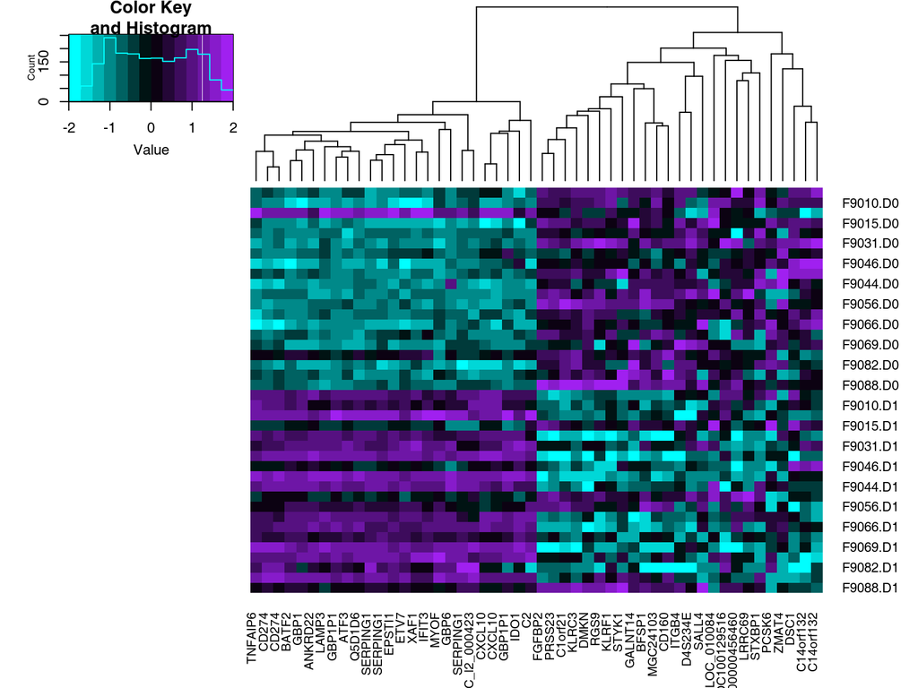

```r
library(gplots)
mtx <- t(e[sel, csel])

## scale manually
mtx <- scale(mtx)

## palette
pal <- colorRampPalette(c("cyan", "black", "purple"))
heatmap.2(mtx, trace="n", scale="n", dendrogram="c",
  Rowv=FALSE, col=pal,
  breaks=seq(-2, 2, length.out=15) )
```